# Fabi’s Week 6 Homework: Nutrient Dynamics at Maunalua Bay

Author

Fabiola Gonzalez Zamora

## Introduction

- Coastal groundwater can transport nutrients to nearshore ecosystems
- This analysis examines **nutrient concentrations** at site BP in Maunalua Bay
  - Comparison of samples during *different tides and times of day* focusing on:
    - Phosphate,
    - Silicate,
    - Nitrate + Nitrite

## Data Preparation

Steps before analysis:

1. Remove observations with missing values.
2. Separate `Tide_time` into `Tide` and `Time`.
3. Retain observations from Site BP.
4. Reshape three nutrient columns into a tidy, long format.

```r
# Load csv file
ChemData <- read.csv(here("Week_06", "Data", "chemicaldata.csv"))

# Clean data
ChemData_clean <- ChemData |>
  drop_na() |>
  separate_wider_delim(cols = Tide_time,
                       delim = "_",
                       names = c("Tide", "Time"),
                       cols_remove = FALSE) |>
  filter(Site == "BP") |>
  pivot_longer(cols = c(Phosphate, Silicate, NN),
               names_to = "Nutrient",
               values_to = "Concentration")|>
  mutate( # Replace abbreviated variable names with reader-friendly labels
    Nutrient = recode(
      Nutrient,
      Phosphate = "Phosphate",
      Silicate = "Silicate",
      NN = "Nitrate + nitrite"
    ),
    # Control the order shown in tables and figures
    Tide = factor(Tide, levels = c("Low", "High")),
    Time = factor(Time, levels = c("Day", "Night"))
  )
```

## Summary statistics

- Summary of mean concentration, standard deviation, sample size, and standard error for every nutrient, tide, and time-of-day combination
- Results are presented in Table 1

```r
ChemSummary <- ChemData_clean |>
  group_by(Nutrient, Tide, Time) |>
  summarise(mean_concentration = mean(Concentration),
            var_concentration = var(Concentration),
            sd_concentration = sd(Concentration),
            sample_size = n(),
            sd_error = sd_concentration / sqrt(sample_size),
            .groups = "drop")

# Save the summary statistics in the Week 6 output folder
write_csv(
  ChemSummary,
  here("Week_06", "Output", "chemistry_summary.csv"))
```

Table 1: Nutrient concentrations at Site BP by Tide and Time of Day

| Nutrient | Tide | Time of day | Mean | Variance | Standard deviation | Sample size | Standard error |
| --- | --- | --- | --- | --- | --- | --- | --- |
| Nitrate + nitrite | Low | Day | 5.51 | 66.9781840 | 8.18 | 35 | 1.38 |
| Nitrate + nitrite | Low | Night | 4.20 | 21.4611512 | 4.63 | 40 | 0.73 |
| Nitrate + nitrite | High | Day | 0.49 | 0.1448113 | 0.38 | 39 | 0.06 |
| Nitrate + nitrite | High | Night | 1.24 | 2.5278866 | 1.59 | 39 | 0.25 |
| Phosphate | Low | Day | 0.26 | 0.0411176 | 0.20 | 35 | 0.03 |
| Phosphate | Low | Night | 0.23 | 0.0161221 | 0.13 | 40 | 0.02 |
| Phosphate | High | Day | 0.14 | 0.0008754 | 0.03 | 39 | 0.00 |
| Phosphate | High | Night | 0.17 | 0.0030605 | 0.06 | 39 | 0.01 |
| Silicate | Low | Day | 30.22 | 1299.5627252 | 36.05 | 35 | 6.09 |
| Silicate | Low | Night | 20.98 | 453.7806379 | 21.30 | 40 | 3.37 |
| Silicate | High | Day | 5.76 | 25.5963449 | 5.06 | 39 | 0.81 |
| Silicate | High | Night | 8.69 | 80.4759822 | 8.97 | 39 | 1.44 |

## Nutrient Patterns

- Figure 1 compares mean nutrient concentrations between high and low tides
  - Bars separated by time of day, error bars represent **one standard error above and below the means**

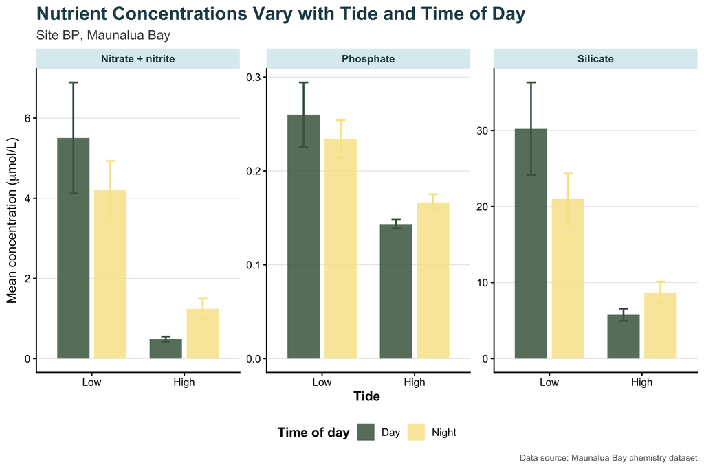

Figure 1: Mean nutrient concentrations at Site BP by tide and time of day. Error bars represent ±1 standard error.

## Interpretation

The results show that nutrient concentrations are **not uniform** across sampling conditions. Silicate occurs at a much higher concentration than the other nutrients, which is why each panel in Figure 1 uses its own vertical scale.

Some considerations: - the bars show group means, not individual observations; - error bars show uncertainty around each mean; - this visualization describes patterns but does not test statistical significance.

Overall, the table and figure provide *complementary views* of the same chemistry data: Table 1 provides precise values, while Figure 1 makes the major patterns easier to compare.

## Data Sources

The analysis uses the Maunalua Bay chemistry dataset supplied for OCN 682/MBIO 612.